# AN597: Homework 04

majo

19/10/2019

## Problem 1:

The biggest issue is writing the function code. I didn’t include all the parameters and only try one sample Z-test. Also, I cannot include the equation in the plot

## Problem 2:

I cannot bind two data frames to create the plot for predicted CI and the plot for the linear regression I have no idea how to fix that #Conolidating all data into one dataframe: Error in data.frame(…, check.names = FALSE) : arguments imply differing number of rows: 213, 128

# Question 1

[1] Write a simple R function, Z.prop.test(), that can perform one- or two-sample Z-tests for proportion data, using the following guidelines: Your function should take the following arguments: p1 and n1 (no default) representing the estimated proportion and sample size (i.e., based on your sample data); p2 and n2 (both defaulting to NULL) that contain a second sample’s proportion and sample size data in the event of a two-sample test; p0 (no default) as the expected value for the population proportion; and alternative (default “two.sided”) and conf.level (default 0.95), to be used in the same way as in the function t.test(). When conducting a two-sample test, it should be p1 that is tested as being smaller or larger than p2 when alternative=“less” or alternative=“greater”, the same as in the use of x and y in the function t.test().

The function should perform a one-sample Z-test using p1, n1, and p0 if either p2 or n2 (or both) is NULL.

The function should contain a check for the rules of thumb we have talked about (n∗p>5 and n∗(1−p)>5) to ensure the validity of assuming the normal distribution in both the one- and two-sample settings. If this is violated, the function should still complete but it should also print an appropriate warning message. The function should return a list containing the members Z (the test statistic), P (the appropriate p value), and CI (the two-sided CI with respect to “conf.level” around p1 in the case of a one-sample test and around p2-p1 in the case of a two-sample test). For all test alternatives (“two.sided”, “greater”, “less”), calculate symmetric CIs based on quantiles of the normal distribution rather than worrying about calculating single-limit confidence bounds.

```r
Z.prop.test  <- function(x,n,p=NULL,conf.level=0.95,alternative="less") {
   ts.z <- NULL
   cint <- NULL
   p.val <- NULL
      phat <- x/n  #estimated proportion
      qhat <- 1 - phat

      if(length(p) > 0) {
         q <- 1-p
         SE.phat <- sqrt((p*q)/n)
         ts.z <- (phat - p)/SE.phat
         p.val <- pnorm(ts.z)
         if(alternative=="two.sided") {
            p.val <- p.val * 2
         }
         if(alternative=="greater") {
            p.val <- 1 - p.val
         }

      }
       cint <- phat + c(
         -1*((qnorm(((1 - conf.level)/2) + conf.level))*SE.phat),
         ((qnorm(((1 - conf.level)/2) + conf.level))*SE.phat) )

   return(list(estimate=phat,ts.z=ts.z,p.val=p.val,cint=cint))
      }

Z.prop.test(150,360, p=0.90)
```

```
## $estimate
## [1] 0.4166667
##
## $ts.z
## [1] -30.56868
##
## $p.val
## [1] 1.596382e-205
##
## $cint
## [1] 0.3856769 0.4476564
```

# Question 2

The dataset from Kamilar and Cooper has in it a large number of variables related to life history and body size. For this exercise, the end aim is to fit a simple linear regression model to predict longevity (MaxLongevity_m) measured in months from species’ brain size (Brain_Size_Species_Mean) measured in grams. Do the following for both longevity~brain size and log(longevity)~log(brain size):

z.test(312,360, p=0.9)

```r
library(curl)
f <- curl("https://raw.githubusercontent.com/fuzzyatelin/fuzzyatelin.github.io/master/AN597_Fall19/KamilarAndCooperData.csv")
d <- read.csv(f, header = TRUE, sep = ",", stringsAsFactors = TRUE)
head(d)
```

```
##               Scientific_Name          Family          Genus      Species
## 1 Allenopithecus_nigroviridis Cercopithecidae Allenopithecus nigroviridis
## 2         Allocebus_trichotis Cercopithecidae      Allocebus    trichotis
## 3           Alouatta_belzebul        Atelidae       Alouatta     belzebul
## 4             Alouatta_caraya        Atelidae       Alouatta       caraya
## 5            Alouatta_guariba        Atelidae       Alouatta      guariba
## 6           Alouatta_palliata        Atelidae       Alouatta     palliata
##   Brain_Size_Species_Mean Brain_Size_Female_Mean   Brain_size_Ref
## 1                   58.02                  53.70 Isler et al 2008
## 2                      NA                     NA
## 3                   52.84                  51.19 Isler et al 2008
## 4                   52.63                  47.80 Isler et al 2008
## 5                   51.70                  49.08 Isler et al 2008
## 6                   49.88                  48.04 Isler et al 2008
##   Body_mass_male_mean Body_mass_female_mean Mass_Dimorphism
```

[output cut: 69 more lines]

## 1. Fit the regression model and, using {ggplot2}, produce a scatterplot with the fitted line superimposed upon the data. Append the the fitted model equation to your plot (HINT: use the function geom_text()).

## 2. Identify and interpret the point estimate of the slope (β1), as well as the outcome of the test associated with the hypotheses H0: β1 = 0; HA: β1 ≠ 0. Also, find a 90 percent CI for the slope (β1) parameter.

## 3. Using your model, add lines for the 90 percent confidence and prediction interval bands on the plot and add a legend to differentiate between the lines.

```r
library(ggplot2)
library(car)
m<- lm(data = d, MaxLongevity_m ~ Brain_Size_Species_Mean)
m
```

```
##
## Call:
## lm(formula = MaxLongevity_m ~ Brain_Size_Species_Mean, data = d)
##
## Coefficients:
##             (Intercept)  Brain_Size_Species_Mean
##                 248.952                    1.218
```

```r
summary(m)
```

```
##
## Call:
## lm(formula = MaxLongevity_m ~ Brain_Size_Species_Mean, data = d)
##
## Residuals:
##     Min      1Q  Median      3Q     Max
## -198.27  -61.92  -17.78   56.16  331.36
##
## Coefficients:
##                         Estimate Std. Error t value Pr(>|t|)
## (Intercept)             248.9523    11.1111   22.41   <2e-16 ***
## Brain_Size_Species_Mean   1.2180     0.1101   11.06   <2e-16 ***
## ---
## Signif. codes:  0 '***' 0.001 '**' 0.01 '*' 0.05 '.' 0.1 ' ' 1
##
## Residual standard error: 90.91 on 126 degrees of freedom
##   (85 observations deleted due to missingness)
## Multiple R-squared:  0.4928, Adjusted R-squared:  0.4887
## F-statistic: 122.4 on 1 and 126 DF,  p-value: < 2.2e-16
```

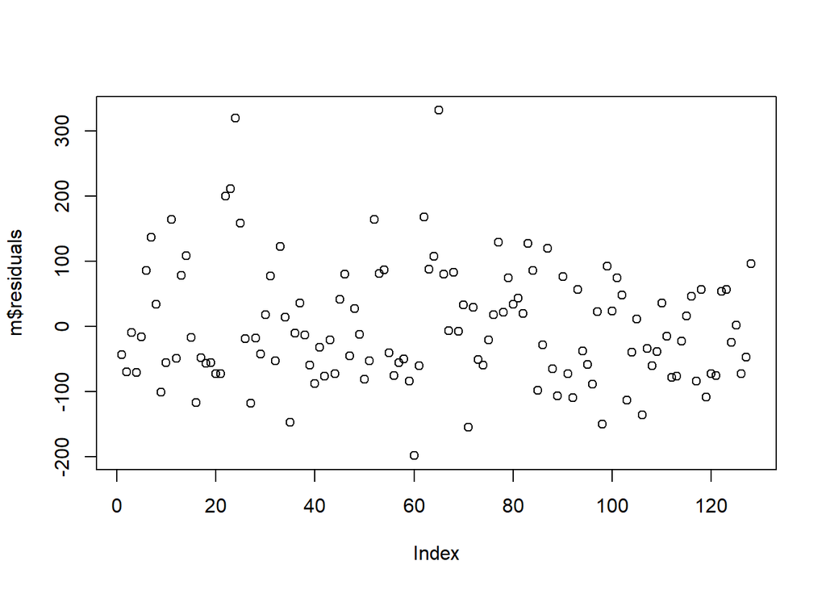

```r
plot(m$residuals)
```

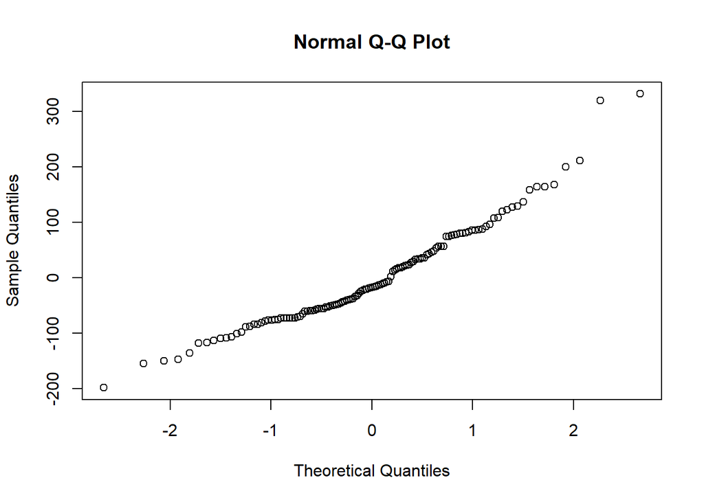

```r
qqnorm(m$residuals)
```

```r
confint(m, level = 0.90)
```

```
##                                5 %      95 %
## (Intercept)             230.540738 267.36379
## Brain_Size_Species_Mean   1.035571   1.40041
```

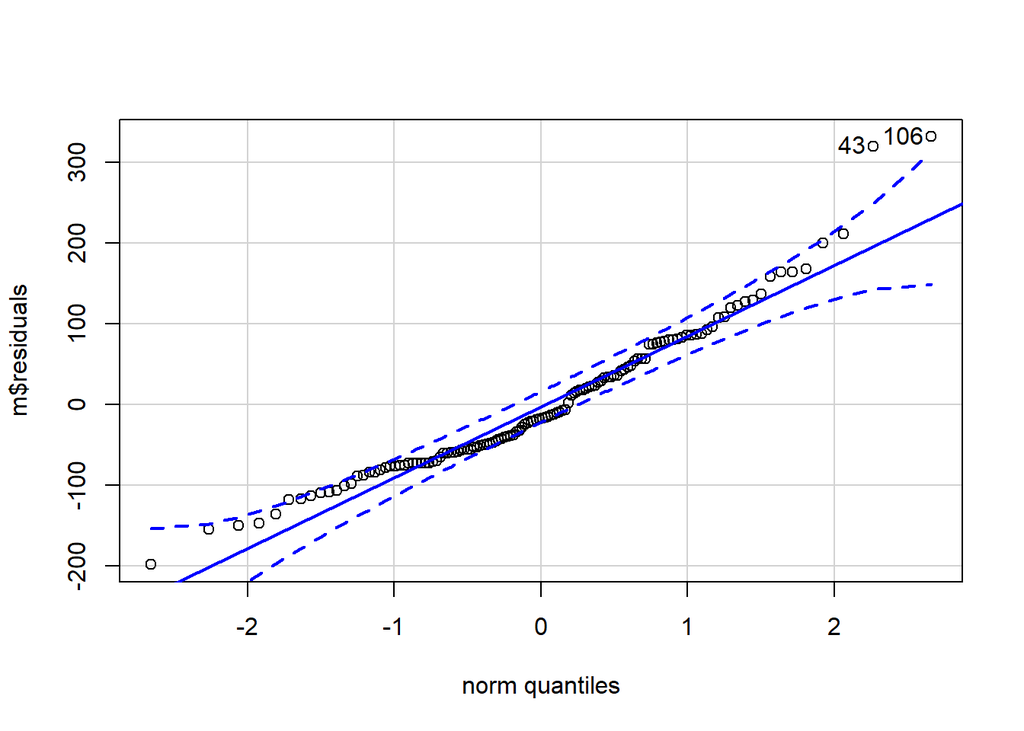

```
## 106  43
##  65  24
```

```r
qqPlot(m$residuals)
```

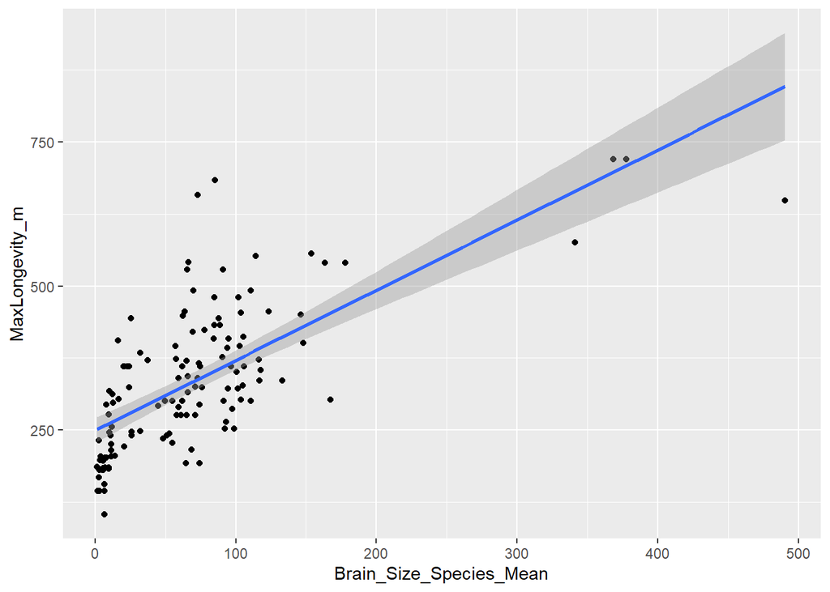

```r
g <- ggplot(data = d, aes(x = Brain_Size_Species_Mean, y = MaxLongevity_m))
g <- g + geom_point()
g <- g + geom_smooth(method = "lm", formula = y ~ x)
g
```

```r
# Calculating confidence intervals
temp_var <- predict(m, interval="prediction")
temp_var
```

```
##          fit       lwr       upr
## 1   319.6201 138.99074  500.2494
## 4   313.0551 132.40540  493.7048
## 6   309.7056 129.04260  490.3686
## 7   311.2281 130.57139  491.8848
## 8   316.2097 135.57074  496.8486
## 9   274.1281  93.20107  455.0552
## 11  268.8055  87.81974  449.7913
## 14  269.4754  88.49730  450.4535
## 16  257.3808  76.25213  438.5094
## 17  391.4815 210.57622  572.3868
## 18  388.0955 207.22370  568.9673
## 19  376.9509 196.17506  557.7267
## 20  375.4406 194.67607  556.2051
## 24  383.7594 202.92760  564.5913
```

[output cut: 114 more lines]

```r
# Conolidating all data into one dataframe
#new_df<- cbind (d, temp_var) ### does not work

#head(new_df)



#ggplot(data= new_df)+ aes(x= Brain_Size_Species_Mean, y= MaxLongevity_m)+
    #geom_point() +
    #geom_line(aes(y=lwr), color = "red", linetype = "dashed")+
    #geom_line(aes(y=upr), color = "red", linetype = "dashed")+
    #geom_smooth(method=lm, se=TRUE)+
```

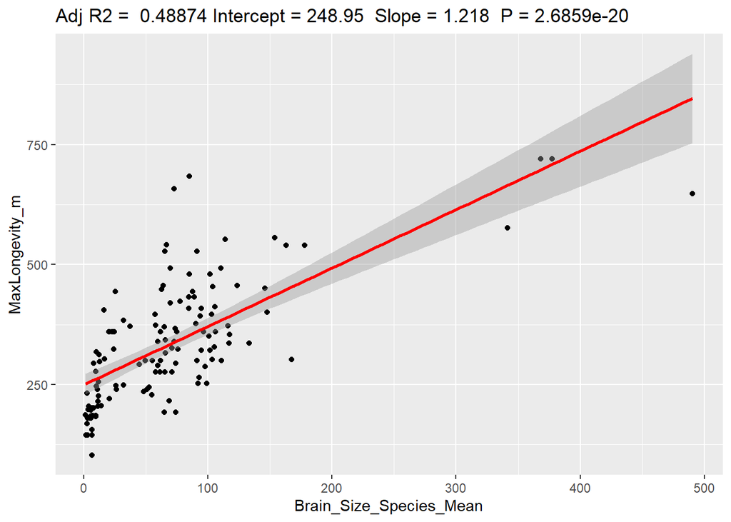

```r
## headlines
ggplotRegression <- function (fit) {

require(ggplot2)

ggplot(fit$model, aes_string(x = names(fit$model)[2], y = names(fit$model)[1])) +
  geom_point() +
  stat_smooth(method = "lm", col = "red") +
  labs(title = paste("Adj R2 = ",signif(summary(fit)$adj.r.squared, 5),
                     "Intercept =",signif(fit$coef[[1]],5 ),
                     " Slope =",signif(fit$coef[[2]], 5),
                     " P =",signif(summary(fit)$coef[2,4], 5)))
}


ggplotRegression(lm(data = d, MaxLongevity_m ~ Brain_Size_Species_Mean))
```

## 4. Produce a point estimate and associated 90 percent PI for the longevity of a species whose brain weight is 800 gm. Do you trust the model to predict observations accurately for this value of the explanatory variable? Why or why not?

```r
ci<- predict(m, newdata = data.frame(Brain_Size_Species_Mean = 800), interval = "confidence", level = 0.90)

ci
```

```
##        fit      lwr      upr
## 1 1223.345 1089.461 1357.228
```

```r
PI<- predict(m, newdata = data.frame(Brain_Size_Species_Mean = 800), interval = "prediction", level = 0.90)

PI
```

```
##        fit      lwr      upr
## 1 1223.345 1021.805 1424.884
```

## Log data model

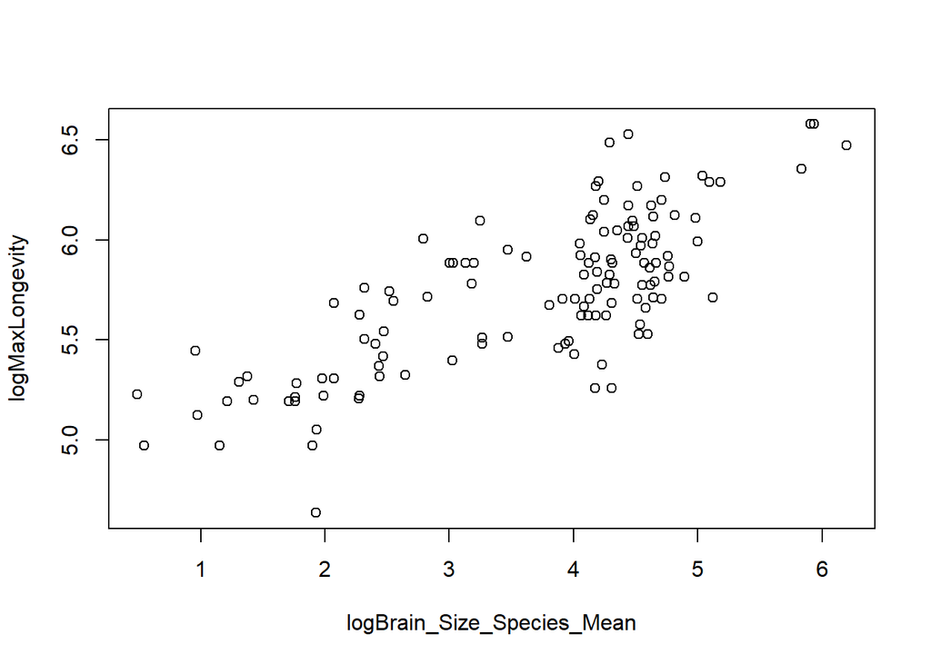

```r
d$logMaxLongevity<-log(d$MaxLongevity_m)
d$logBrain_Size_Species_Mean<-log(d$Brain_Size_Species_Mean)
plot(data=d, logMaxLongevity~logBrain_Size_Species_Mean)
```

```r
model<-lm(data=d, logMaxLongevity~logBrain_Size_Species_Mean)
model
```

```
##
## Call:
## lm(formula = logMaxLongevity ~ logBrain_Size_Species_Mean, data = d)
##
## Coefficients:
##                (Intercept)  logBrain_Size_Species_Mean
##                     4.8790                      0.2341
```

```r
summary(model)
```

```
##
## Call:
## lm(formula = logMaxLongevity ~ logBrain_Size_Species_Mean, data = d)
##
## Residuals:
##     Min      1Q  Median      3Q     Max
## -0.6955 -0.1750 -0.0097  0.1788  0.6084
##
## Coefficients:
##                            Estimate Std. Error t value Pr(>|t|)
## (Intercept)                 4.87895    0.06907   70.63   <2e-16 ***
## logBrain_Size_Species_Mean  0.23415    0.01781   13.15   <2e-16 ***
## ---
## Signif. codes:  0 '***' 0.001 '**' 0.01 '*' 0.05 '.' 0.1 ' ' 1
##
## Residual standard error: 0.2485 on 126 degrees of freedom
##   (85 observations deleted due to missingness)
## Multiple R-squared:  0.5784, Adjusted R-squared:  0.5751
## F-statistic: 172.9 on 1 and 126 DF,  p-value: < 2.2e-16
```

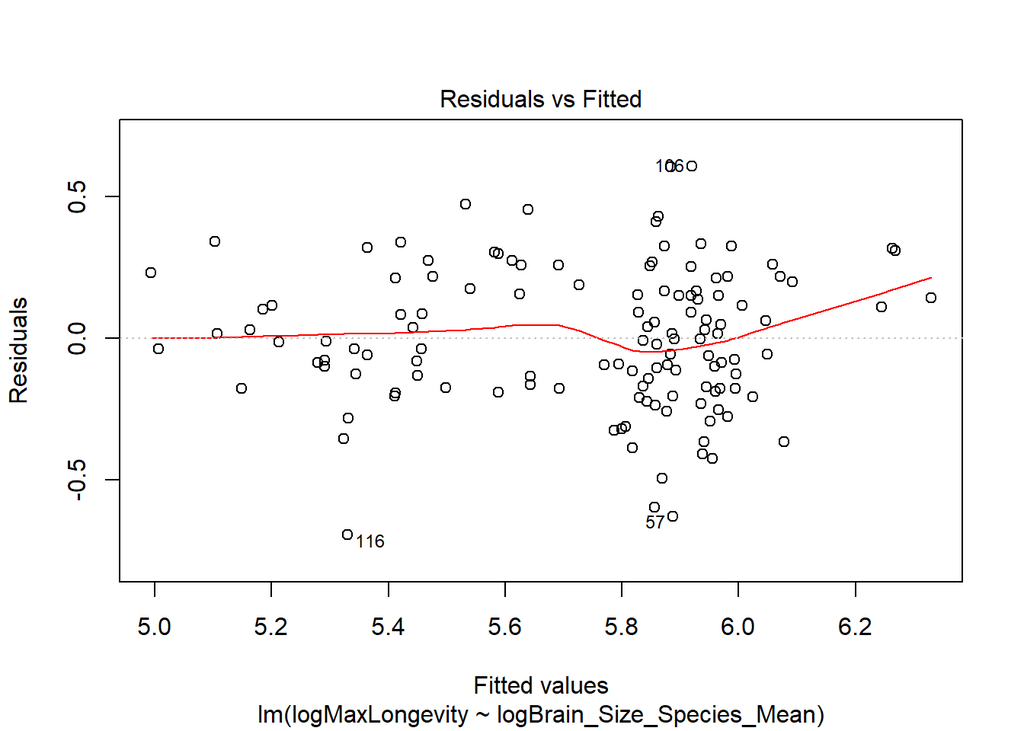

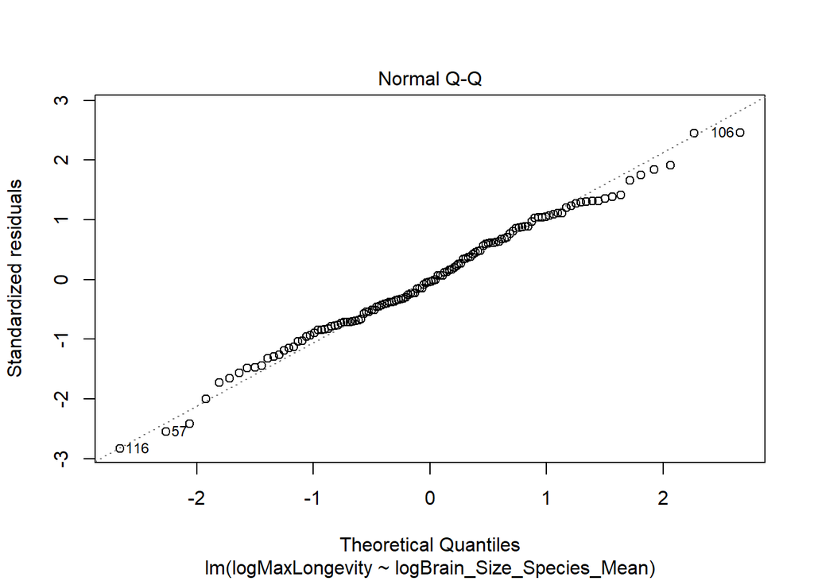

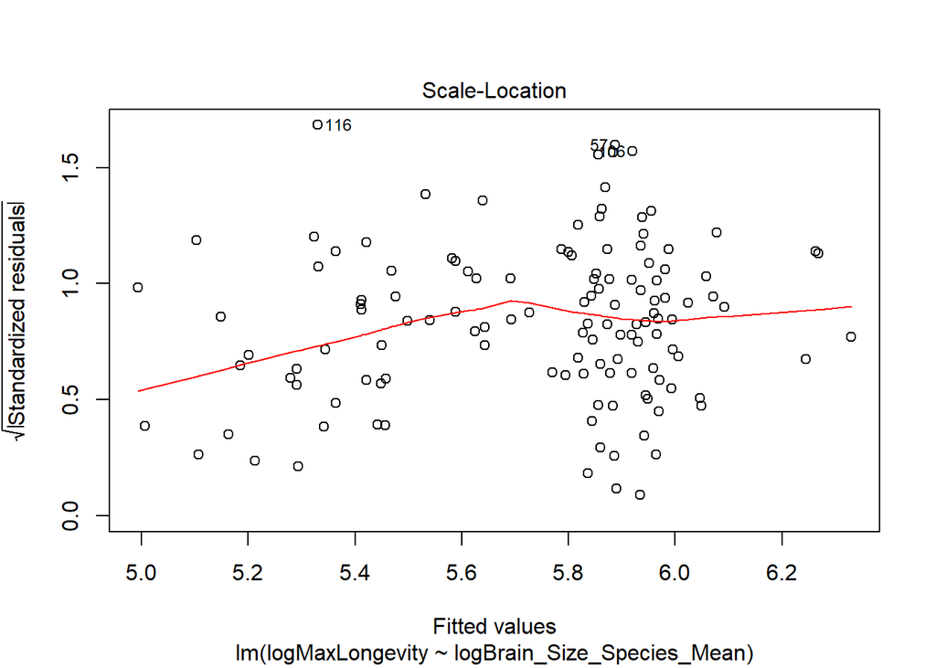

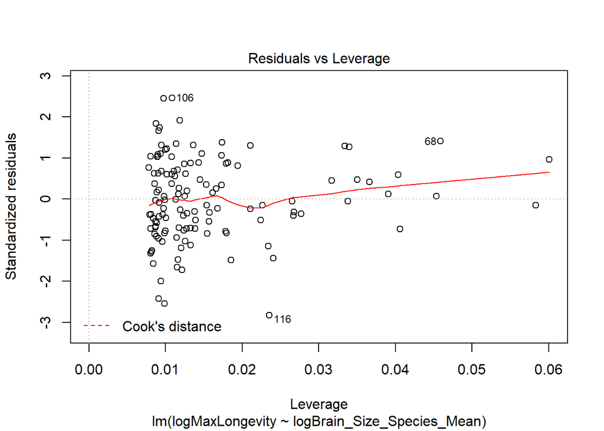

```r
plot(model)
```

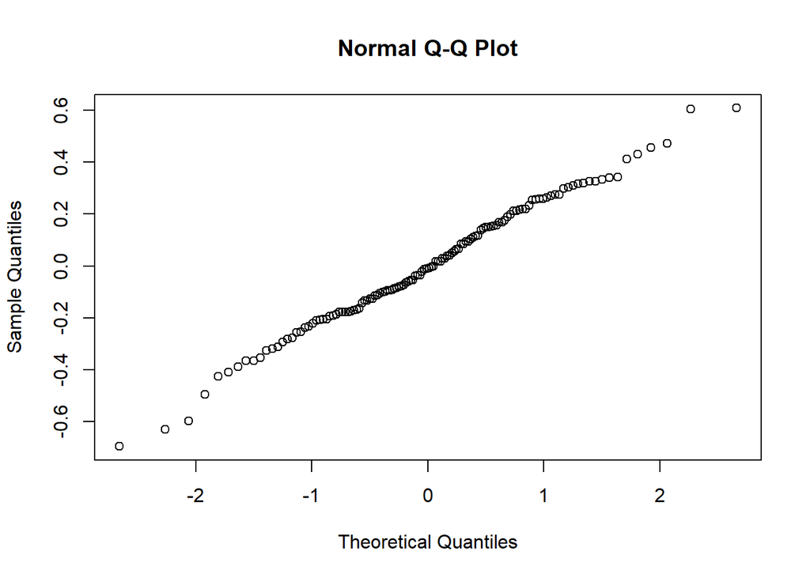

```r
qqnorm(model$residuals)
```

```r
confint(model, level = 0.90)
```

```
##                                  5 %      95 %
## (Intercept)                4.7644934 4.9934084
## logBrain_Size_Species_Mean 0.2046396 0.2636595
```

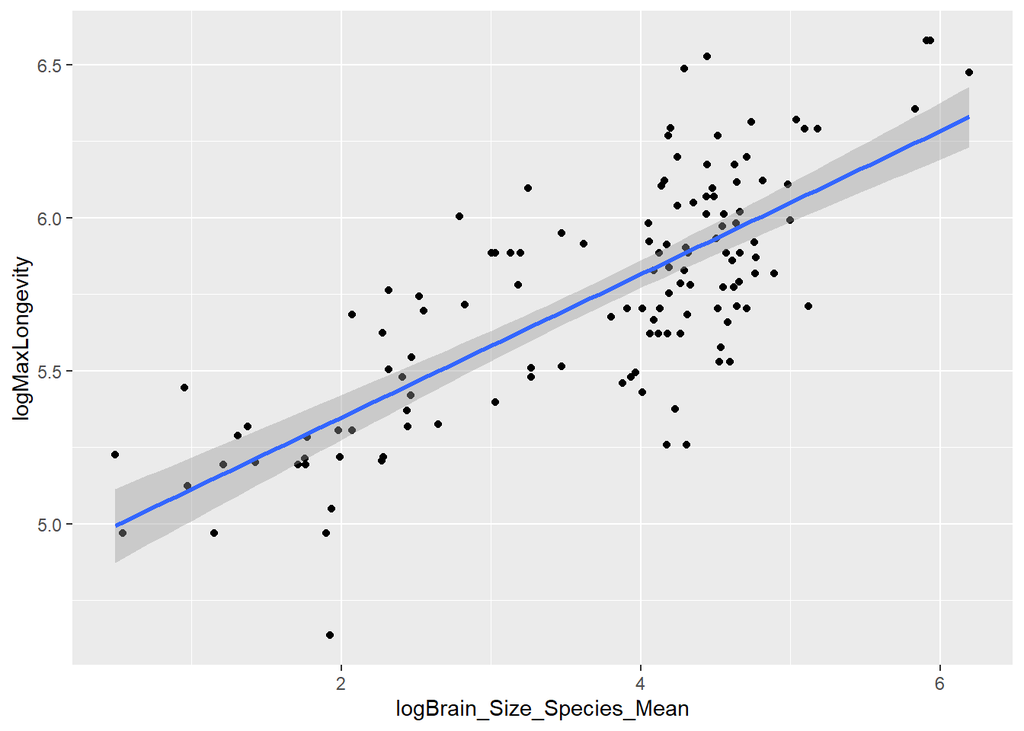

```r
g1 <- ggplot(data = d, aes(x = logBrain_Size_Species_Mean, y = logMaxLongevity))
g1 <- g1 + geom_point()
g1 <- g1 + geom_smooth(method = "lm")
g1
```

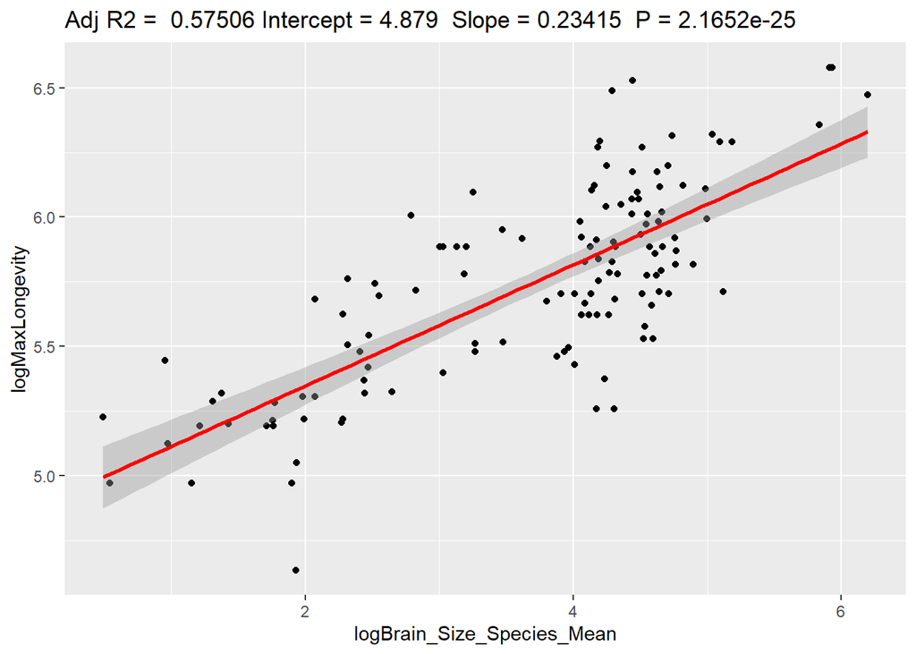

```r
ggplotRegression(lm(data = d, logMaxLongevity ~ logBrain_Size_Species_Mean))
```

5. Looking at your two models, which do you think is better? Why?